# boston_eda

```python
import matplotlib.pyplot as plt
import numpy as np
import optuna
import pandas as pd
import seaborn as sns
import xgboost as xgb
from sklearn import preprocessing
from sklearn.linear_model import LinearRegression
from sklearn.metrics import mean_absolute_error
from sklearn.model_selection import cross_val_score, train_test_split
```

Primero importaremos el dataset y visualizaremos las primeras filas para saber con qué estamos trabajando.

```python
df = pd.read_csv("portfolio-ia1/boston/dataset.csv")
df.head(10)
```

|  | CRIM | ZN | INDUS | CHAS | NOX | RM | AGE | DIS | RAD | TAX | PTRATIO | B | LSTAT | MEDV |
| --- | --- | --- | --- | --- | --- | --- | --- | --- | --- | --- | --- | --- | --- | --- |
| 0 | 0.00632 | 18.0 | 2.31 | 0.0 | 0.538 | 6.575 | 65.2 | 4.0900 | 1.0 | 296.0 | 15.3 | 396.90 | 4.98 | 24.0 |
| 1 | 0.02731 | 0.0 | 7.07 | 0.0 | 0.469 | 6.421 | 78.9 | 4.9671 | 2.0 | 242.0 | 17.8 | 396.90 | 9.14 | 21.6 |
| 2 | 0.02729 | 0.0 | 7.07 | 0.0 | 0.469 | 7.185 | 61.1 | 4.9671 | 2.0 | 242.0 | 17.8 | 392.83 | 4.03 | 34.7 |
| 3 | 0.03237 | 0.0 | 2.18 | 0.0 | 0.458 | 6.998 | 45.8 | 6.0622 | 3.0 | 222.0 | 18.7 | 394.63 | 2.94 | 33.4 |
| 4 | 0.06905 | 0.0 | 2.18 | 0.0 | 0.458 | 7.147 | 54.2 | 6.0622 | 3.0 | 222.0 | 18.7 | 396.90 | 5.33 | 36.2 |
| 5 | 0.02985 | 0.0 | 2.18 | 0.0 | 0.458 | 6.430 | 58.7 | 6.0622 | 3.0 | 222.0 | 18.7 | 394.12 | 5.21 | 28.7 |
| 6 | 0.08829 | 12.5 | 7.87 | 0.0 | 0.524 | 6.012 | 66.6 | 5.5605 | 5.0 | 311.0 | 15.2 | 395.60 | 12.43 | 22.9 |
| 7 | 0.14455 | 12.5 | 7.87 | 0.0 | 0.524 | 6.172 | 96.1 | 5.9505 | 5.0 | 311.0 | 15.2 | 396.90 | 19.15 | 27.1 |
| 8 | 0.21124 | 12.5 | 7.87 | 0.0 | 0.524 | 5.631 | 100.0 | 6.0821 | 5.0 | 311.0 | 15.2 | 386.63 | 29.93 | 16.5 |
| 9 | 0.17004 | 12.5 | 7.87 | 0.0 | 0.524 | 6.004 | 85.9 | 6.5921 | 5.0 | 311.0 | 15.2 | 386.71 | 17.10 | 18.9 |

```python
df.dtypes
```

```
CRIM       float64
ZN         float64
INDUS      float64
CHAS       float64
NOX        float64
RM         float64
AGE        float64
DIS        float64
RAD        float64
TAX        float64
PTRATIO    float64
B          float64
LSTAT      float64
MEDV       float64
dtype: object
```

Revisando los tipos de las columnas, vemos que son todas de tipo float. Estas columnas significan:

- **CRIM** - tasa de criminalidad per cápita por ciudad
- **ZN** - proporción de terrenos residenciales zonificados para lotes de más de 25,000 pies cuadrados
- **INDUS** - proporción de acres de negocios no minoristas por ciudad
- **CHAS** - variable ficticia del río Charles (1 si el sector limita con el río; 0 de lo contrario)
- **NOX** - concentración de óxidos de nitrógeno (partes por 10 millones)
- **RM** - número promedio de habitaciones por vivienda
- **AGE** - proporción de unidades ocupadas por propietarios construidas antes de 1940
- **DIS** - distancias ponderadas a cinco centros de empleo en Boston
- **RAD** - índice de accesibilidad a las autopistas radiales
- **TAX** - tasa de impuesto a la propiedad de valor total por cada $10,000
- **PTRATIO** - relación alumno-profesor por ciudad
- **B** - 1000(Bk - 0.63)² donde Bk es la proporción de negros por ciudad
- **LSTAT** - % de estatus inferior de la población
- **MEDV** - valor medio de las viviendas ocupadas por propietarios en miles de dólares

Lo que salta a la vista es la variable B, la cual como bien podemos ver, es sesgada étnicamente. Esto no debería haber sido un dato tomado en cuenta, así que la quitaremos del dataset.

```python
df = df.drop(columns=["B"])
df.columns
```

```
Index(['CRIM', 'ZN', 'INDUS', 'CHAS', 'NOX', 'RM', 'AGE', 'DIS', 'RAD', 'TAX',
       'PTRATIO', 'LSTAT', 'MEDV'],
      dtype='object')
```

Por otro lado, nuestra variable objetivo sería `MEDV`, así que la usaremos como referencia en futuros ploteos. Continuando, veamos si hay `missing values` en el dataset.

```python
df.isna().sum()
```

```
CRIM       0
ZN         0
INDUS      0
CHAS       0
NOX        0
RM         0
AGE        0
DIS        0
RAD        0
TAX        0
PTRATIO    0
LSTAT      0
MEDV       0
dtype: int64
```

Tal parece que no hay ninguno. Continuemos con la descripción de las variables.

```python
df.describe()
```

|  | CRIM | ZN | INDUS | CHAS | NOX | RM | AGE | DIS | RAD | TAX | PTRATIO | LSTAT | MEDV |
| --- | --- | --- | --- | --- | --- | --- | --- | --- | --- | --- | --- | --- | --- |
| count | 506.000000 | 506.000000 | 506.000000 | 506.000000 | 506.000000 | 506.000000 | 506.000000 | 506.000000 | 506.000000 | 506.000000 | 506.000000 | 506.000000 | 506.000000 |
| mean | 3.613524 | 11.363636 | 11.136779 | 0.069170 | 0.554695 | 6.284634 | 68.574901 | 3.795043 | 9.549407 | 408.237154 | 18.455534 | 12.653063 | 22.532806 |
| std | 8.601545 | 23.322453 | 6.860353 | 0.253994 | 0.115878 | 0.702617 | 28.148861 | 2.105710 | 8.707259 | 168.537116 | 2.164946 | 7.141062 | 9.197104 |
| min | 0.006320 | 0.000000 | 0.460000 | 0.000000 | 0.385000 | 3.561000 | 2.900000 | 1.129600 | 1.000000 | 187.000000 | 12.600000 | 1.730000 | 5.000000 |
| 25% | 0.082045 | 0.000000 | 5.190000 | 0.000000 | 0.449000 | 5.885500 | 45.025000 | 2.100175 | 4.000000 | 279.000000 | 17.400000 | 6.950000 | 17.025000 |
| 50% | 0.256510 | 0.000000 | 9.690000 | 0.000000 | 0.538000 | 6.208500 | 77.500000 | 3.207450 | 5.000000 | 330.000000 | 19.050000 | 11.360000 | 21.200000 |
| 75% | 3.677083 | 12.500000 | 18.100000 | 0.000000 | 0.624000 | 6.623500 | 94.075000 | 5.188425 | 24.000000 | 666.000000 | 20.200000 | 16.955000 | 25.000000 |
| max | 88.976200 | 100.000000 | 27.740000 | 1.000000 | 0.871000 | 8.780000 | 100.000000 | 12.126500 | 24.000000 | 711.000000 | 22.000000 | 37.970000 | 50.000000 |

Lo que podemos ver de forma rápida es los cuartiles de `ZN` y `CHAS`, que en 25 y 50% tienen ambas valores 0, incluso `CHAS` también lo tiene para el cuartil 75%. Por otro lado, el máximo valor de `MEDV`, que haciendo un poco de investigación, parece fue limitado a ese 50.

Ahora veamos la cantidad de outliers para cada columna.

```python
for k, v in df.items():
    q1 = v.quantile(0.25)
    q3 = v.quantile(0.75)
    irq = q3 - q1
    v_col = v[(v <= q1 - 1.5 * irq) | (v >= q3 + 1.5 * irq)]
    perc = np.shape(v_col)[0] * 100.0 / np.shape(df)[0]
    print("%s outliers = %.2f%%" % (k, perc))
```

```
CRIM outliers = 13.04%
ZN outliers = 13.44%
INDUS outliers = 0.00%
CHAS outliers = 100.00%
NOX outliers = 0.00%
RM outliers = 5.93%
AGE outliers = 0.00%
DIS outliers = 0.99%
RAD outliers = 0.00%
TAX outliers = 0.00%
PTRATIO outliers = 2.96%
LSTAT outliers = 1.38%
MEDV outliers = 7.91%
```

De nuevo, `CHAS` se muestra particular, ahora con un 100% de outliers, que se debe a como se comporta la variable. Esto hace que pueda ser difícil de usarla en un modelo. `ZN` y `CRIM` también tienen porcentajes altos de outliers, pudiendo significar esto que hay zonas con muy altos / bajos porcentaje de crimen o una cantidad desproporcionada de áreas residenciales. El resto de las features predictivas no tienen una cantidad significativamente infueyente de outliers. `MEDV` tiene un porcentaje de outliers el cual deberíamos tener en cuenta, siendo que esto representa casas que valen mucho más/menos, y puede alterar a la predicción del modelo. Aún siendo outliers, estos datos pueden representar partes de la realidad necesarias. Por eso, en un principio no voy a tocar a las features predictivas. Podría ser bueno quitar los outliers de `MEDV`, existiendo la posibilidad de que una casa sea más valorizada por algo externo a ella como podría ser que un famoso vivió ahí.

```python
df = df[~(df["MEDV"] >= 50.0)]
```

Siguiendo, veamos la correlacción entre features.

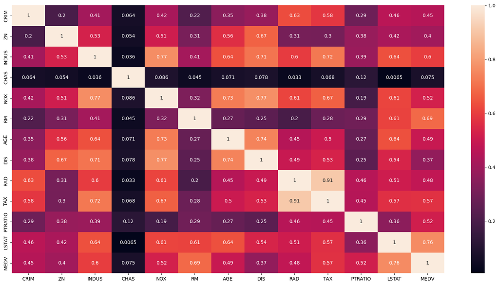

```python
plt.figure(figsize=(20, 10))
sns.heatmap(df.corr().abs(), annot=True)
```

Vamos a borrar las columnas correlacionadas y volver a graficar.

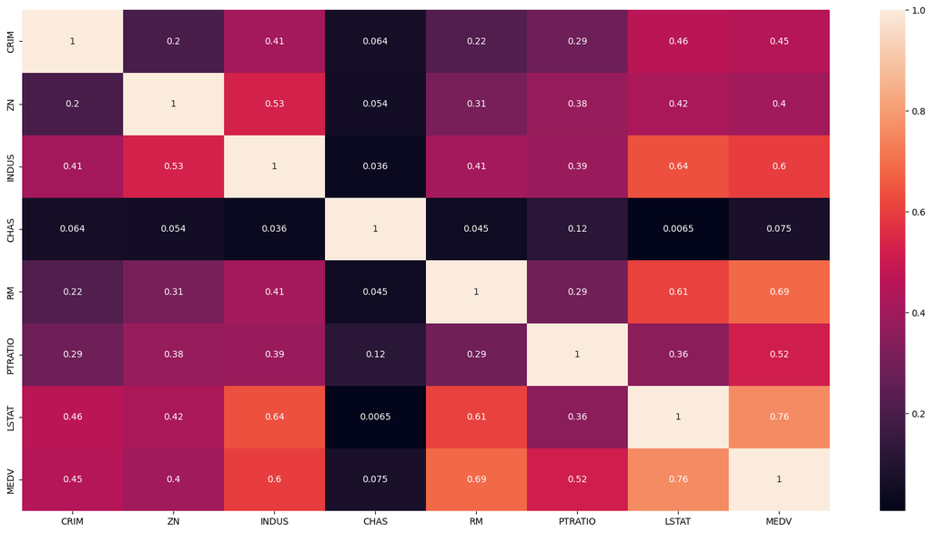

```python
df = df.drop(columns=["DIS", "NOX", "RAD", "TAX", "AGE"])
plt.figure(figsize=(20, 10))
sns.heatmap(df.corr().abs(), annot=True)
```

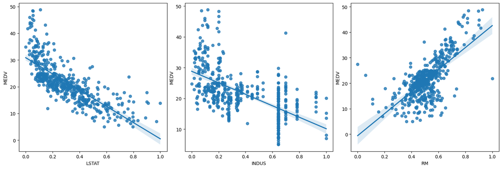

```python
min_max_scaler = preprocessing.MinMaxScaler()
column_sels = ["LSTAT", "INDUS", "RM"]
x = df.loc[:, column_sels]
y = df["MEDV"]
x = pd.DataFrame(data=min_max_scaler.fit_transform(x), columns=column_sels)
fig, axs = plt.subplots(ncols=3, nrows=1, figsize=(15, 5))
index = 0
axs = axs.flatten()
for i, k in enumerate(column_sels):
    sns.regplot(y=y, x=x[k], ax=axs[i])
plt.tight_layout(pad=0.4, w_pad=0.5, h_pad=5.0)
```

Con esto podemos ver las tendencias de `MEDV` respecto a las features elegidas. Por ejemplo, el como disminuye respecto a `INDUS` y `LSTAT` cuando estas aumentan, pero por otro lado aumenta a la par que `RM`

Sigamos con un pairplot, para tener un vistazo general de lo que tenemos hasta ahora.

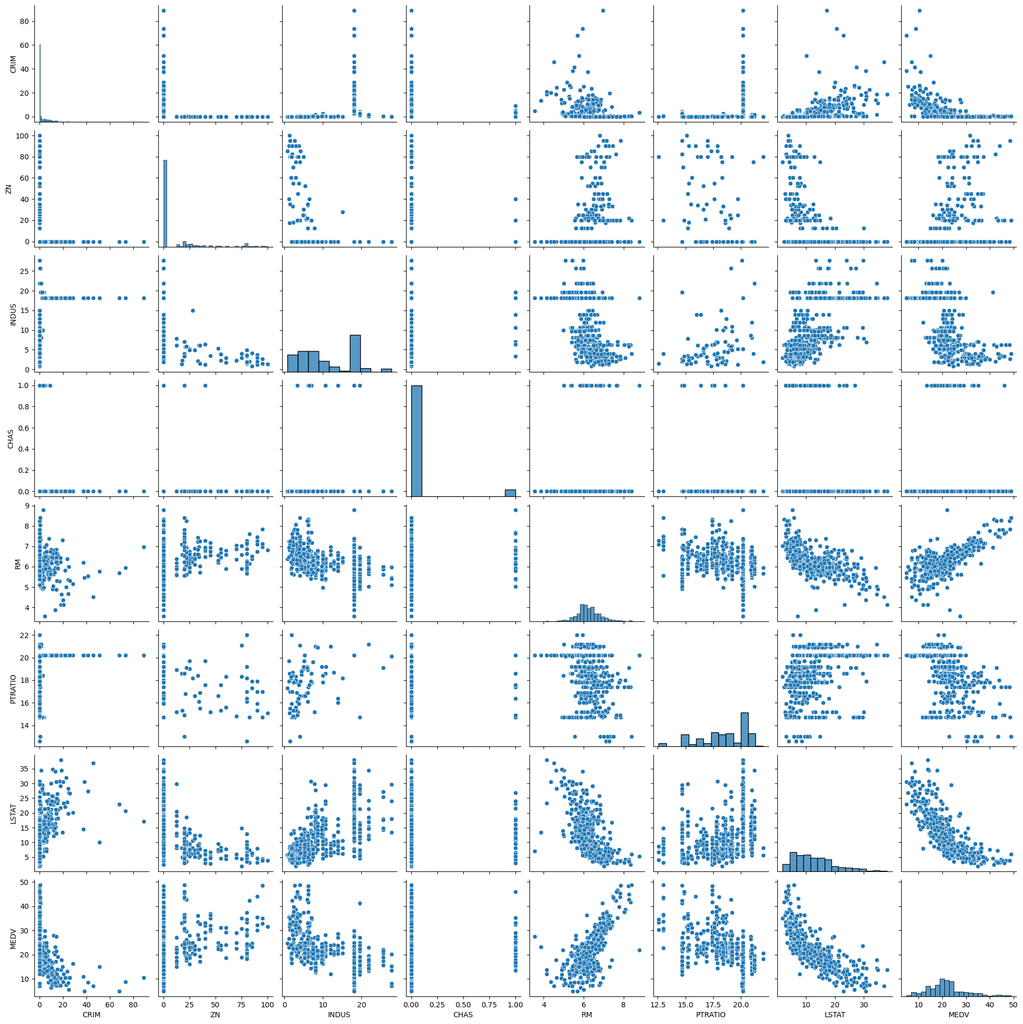

```python
sns.pairplot(df)
```

Algunas columnas (`RM`, `MEDV`) presentan una distribución normal, lo cual puede ayudarnos en la utilización de nuestro modelo. Por otro lado, hay pocas tendencias visibles facilmente. Una podría ser el comportamiento de `LSTAT` hacia `MEDV` mostrando que a medida que desciende el valor de la casa, es mayor el porcentaje de personas de un contexto económico menor en ese barrio. Otra cosa a ver es como aumenta significativamente `CRIM` a medida que `MEDV` disminuye. Esto nos dice que, en barrios con mayor crimen, las casas valen menos. La última tendencia que puedo notar es el aumento del valor de la casa (`MEDV`) a medida que aumentan la cantidad de cuartos `RM`, lo cual tiene sentido y creo no amerita mayor explicación.

Con todo esto, parece que tenemos bastante insight para poder empezar a modelar. Empecemos con una regresión lineal, siendo que las variables parecen ser bastante lineales y esto un problema de regresión, usando **MAE** como métrica. Luego, probaremos con otro modelo, para ver que podemos lograr.

```
Mean Absolute Error: 3.08
```

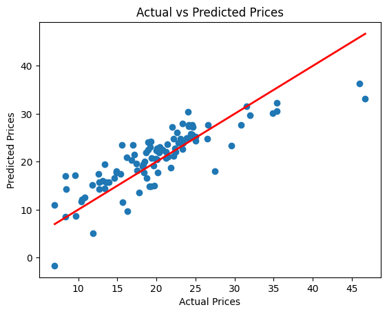

```python
# Split data into features (X) and target (y)
X = df.drop("MEDV", axis=1)  # All features except 'MEDV'
y = df["MEDV"]  # Target variable

# Split the data into training and testing sets
X_train, X_test, y_train, y_test = train_test_split(
    X, y, test_size=0.2, random_state=42
)

# Create a Linear Regression model
model = LinearRegression()

# Train the model using the training data
model.fit(X_train, y_train)

# Make predictions using the testing set
y_pred = model.predict(X_test)

# Evaluate the model
mae = mean_absolute_error(y_test, y_pred)

# Print the results
print(f"Mean Absolute Error: {mae:.2f}")

# Plot predictions vs actual values
plt.scatter(y_test, y_pred)
plt.plot([y_test.min(), y_test.max()], [y_test.min(), y_test.max()], color="red", lw=2)
plt.xlabel("Actual Prices")
plt.ylabel("Predicted Prices")
plt.title("Actual vs Predicted Prices")
plt.show()
```

Podemos ver que el modelo performó bastante bien, con 3 mil dolares de error promedio, lo cual puede ser bastante más o menos significativo, dependiendo de la casa. Siendo que la mayoria de los precios se ubican en el entorno de los 20 y 25 mil dolares, hablamos de poco más de un 10% de error en el valor del hogar. Así, podemos ver que haciendo un correcto tratado de los datos y análisi de estos podemos conseguir un modelo bastante robusto para la predicción, aun siendo a partir de un modelo simple como es la regresión lineal. Para terminar, probemos un modelo más complejo y potente, como lo es `XGBoost`, y comparar resultados. Además, se le añadió optimización de parametros a través de optuna, para ver qué tanto puede, o no, mejorar.

```python
def objective(trial):
    # Define search spaces for hyperparameters
    params = {
        "n_estimators": trial.suggest_int("n_estimators", 100, 1000),
        "max_depth": trial.suggest_int("max_depth", 3, 10),
        "learning_rate": trial.suggest_float("learning_rate", 0.01, 0.3),
        "subsample": trial.suggest_float("subsample", 0.5, 1.0),
        "colsample_bytree": trial.suggest_float("colsample_bytree", 0.5, 1.0),
        "alpha": trial.suggest_float("alpha", 0, 10),
        "lambda": trial.suggest_float("lambda", 0, 10),
    }

    xgbr = xgb.XGBRegressor(
        random_state=42,
        objective="reg:absoluteerror",
        **params,
    )

    # Cross-validation score
    score = cross_val_score(
        xgbr, X_train, y_train, cv=5, scoring="neg_mean_absolute_error"
    )

    # Minimize the negative MAE
    return -np.mean(score)
```

```python
optuna.logging.set_verbosity(optuna.logging.WARNING)
study = optuna.create_study(direction="minimize")
study.optimize(objective, n_trials=50)
best_params = study.best_params
```

```
MAE XGBoost: 2.35
```

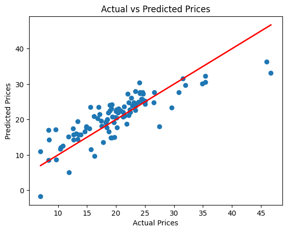

```python
# Create and train the XGBoost model
xgboost_model = xgb.XGBRegressor(
    objective="reg:absoluteerror", random_state=42, **best_params
)
xgboost_model.fit(X_train, y_train)

# Make predictions using the testing set
y_pred_xgb = xgboost_model.predict(X_test)

# Evaluate the XGBoost model
mae_xgb = mean_absolute_error(y_test, y_pred_xgb)
print(f"MAE XGBoost: {mae_xgb:.2f}")
# Plot predictions vs actual values
plt.scatter(y_test, y_pred)
plt.plot([y_test.min(), y_test.max()], [y_test.min(), y_test.max()], color="red", lw=2)
plt.xlabel("Actual Prices")
plt.ylabel("Predicted Prices")
plt.title("Actual vs Predicted Prices")
plt.show()
```

Era esperable que mejorase, tanto por ser un modelo más potente, como utilizar la optimización de parámetros. Hablamos de en promedio, un aproximado de 20% de mejora, lo cual es significativo, y valió la pena la prueba.